# Peak analysis of Ssd1 CRAC data

Edward Wallace

17 Oct 2020

# Summary

This analysis searches for motifs associated with Ssd1-bound RNA from the CRAC datasets. This script relies on Ssd1-bound peak data in .gtf (gff-like) format produced by `pyCalculateFDRs.py` script while running the pipeline, put in the directory `/Ssd1_CRAC_demult_dedup_20190114_all/pyCalculateFDRs_analyses/`.

The objectives are to: * filter Ssd1 CRAC hits by read count and width in addition to FDR * generate fasta files of peak sequences * discover motifs enriched in filtered peaks

It takes as input: * locations of Ssd1-bound peaks, with peak height and false discovery rate (FDR) as output by `pyCalculateFDRs.py` in gff-like format * genome sequence in fasta format (EF4.74 annotation, R64-1-1 genome build)

It outputs, to directory `results`: * sequences associated with filtered peak list, in fasta format * MEME motif analysis of sequences of top 100 peaks.

# Load gtfs

```r
# setwd("~/Repos/Ssd1_CRACanalysis_2020/rmarkdown")
S3_30_df <- read_FDR_gff("../Ssd1_CRAC_demult_dedup_20190114_all/pyCalculateFDRs_analyses/20190114_Ssd1_CRAC_trimmed_NNNGTGAGC_SSD1_3_30_output_FDRs.gtf")
S3_42_df <- read_FDR_gff("../Ssd1_CRAC_demult_dedup_20190114_all/pyCalculateFDRs_analyses/20190114_Ssd1_CRAC_trimmed_NNNAGAGC_SSD1_3_42_output_FDRs.gtf")
S4_30_df <- read_FDR_gff("../Ssd1_CRAC_demult_dedup_20190114_all/pyCalculateFDRs_analyses/20190114_Ssd1_CRAC_trimmed_NNNTGGAGC_SSD1_4_30_output_FDRs.gtf")
S4_42_df <- read_FDR_gff("../Ssd1_CRAC_demult_dedup_20190114_all/pyCalculateFDRs_analyses/20190114_Ssd1_CRAC_trimmed_NNNCTAGC_SSD1_4_42_output_FDRs.gtf")
```

## Sort dataframes

Print top peaks by (deduplicated) coverage in each sample.

```r
S3_30_df %>%
    arrange(desc(peak_height)) %>%
    print_gff_nice()
```

```
## # A tibble: 5,793 x 7
##    chromosome   start     end peak_height strand ID        Gene
##    <chr>        <int>   <int>       <dbl> <chr>  <chr>     <chr>
##  1 chrXIV      501055  501128        7323 +      YNL066W   SUN4
##  2 chrIV      1017207 1017270        3913 -      YDR278C   YDR278C
##  3 chrXII      370037  370099        2898 -      YLR110C   CCW12
##  4 chrXI       519329  519523        2654 +      YKR042W   UTH1
##  5 chrXII      370110  370140        2516 -      YLR110C   CCW12
##  6 chrIX       127491  127637        2049 +      YIL123W   SIM1
##  7 chrXV       797552  797597        2017 +      YOR247W   SRL1
##  8 chrX        121774  121850        2014 +      YJL159W   HSP150
##  9 chrXII      462523  462578        1742 -      YLR154C-G <NA>
## 10 chrXV       797629  797727        1310 +      YOR247W   SRL1
## # … with 5,783 more rows
```

```r
S3_42_df %>%
    arrange(desc(peak_height)) %>%
    print_gff_nice()
```

```
## # A tibble: 5,835 x 7
##    chromosome  start    end peak_height strand ID        Gene
##    <chr>       <int>  <int>       <dbl> <chr>  <chr>     <chr>
##  1 chrX       121721 121857        3359 +      YJL159W   HSP150
##  2 chrXII     370037 370102        2922 -      YLR110C   CCW12
##  3 chrXI      519383 519515        2917 +      YKR042W   UTH1
##  4 chrXII     370111 370136        1853 -      YLR110C   CCW12
##  5 chrVII     883247 883309        1529 -      YGR192C   TDH3
##  6 chrXI      519329 519379        1211 +      YKR042W   UTH1
##  7 chrXI      259243 259325        1001 +      YKL096W-A CWP2
##  8 chrXIV     501056 501135         967 +      YNL066W   SUN4
##  9 chrXII     462525 462593         908 -      YLR154C-G <NA>
## 10 chrXVI      96957  97056         799 -      YPL240C   HSP82
## # … with 5,825 more rows
```

```r
S4_30_df %>%
    arrange(desc(peak_height)) %>%
    print_gff_nice()
```

```
## # A tibble: 3,815 x 7
##    chromosome   start     end peak_height strand ID        Gene
##    <chr>        <int>   <int>       <dbl> <chr>  <chr>     <chr>
##  1 chrXIV      501056  501128        4205 +      YNL066W   SUN4
##  2 chrIV      1017207 1017258        2059 -      YDR278C   YDR278C
##  3 chrXII      370111  370138        2025 -      YLR110C   CCW12
##  4 chrIX       127571  127629        1786 +      YIL123W   SIM1
##  5 chrXI       519323  519513        1611 +      YKR042W   UTH1
##  6 chrXII      370039  370099        1575 -      YLR110C   CCW12
##  7 chrX        121722  121863        1230 +      YJL159W   HSP150
##  8 chrXV       797556  797591        1036 +      YOR247W   SRL1
##  9 chrXV       797670  797716        1014 +      YOR247W   SRL1
## 10 chrXII      462523  462578         983 -      YLR154C-G <NA>
## # … with 3,805 more rows
```

```r
S4_42_df %>%
    arrange(desc(peak_height)) %>%
    print_gff_nice()
```

```
## # A tibble: 10,551 x 7
##    chromosome  start    end peak_height strand ID        Gene
##    <chr>       <int>  <int>       <dbl> <chr>  <chr>     <chr>
##  1 chrXII     370037 370102       11273 -      YLR110C   CCW12
##  2 chrXI      259243 259323        4837 +      YKL096W-A CWP2
##  3 chrXII     370111 370138        4812 -      YLR110C   CCW12
##  4 chrVII     883262 883309        4465 -      YGR192C   TDH3
##  5 chrX       121713 121897        4142 +      YJL159W   HSP150
##  6 chrXI      519388 519521        3590 +      YKR042W   UTH1
##  7 chrXIII    476276 476344        2522 -      YMR105C   PGM2
##  8 chrXIV     501056 501131        2046 +      YNL066W   SUN4
##  9 chrXVI     646055 646112        1865 +      YPR036W-A <NA>
## 10 chrXII     462523 462578        1727 -      YLR154C-G <NA>
## # … with 10,541 more rows
```

# Plot coverage vs FDR

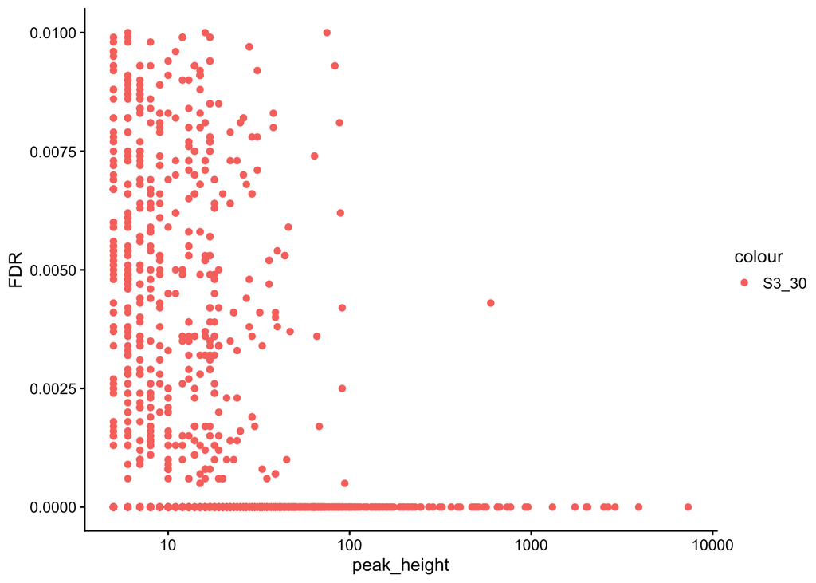

```r
ggplot(data=tibble(),aes(x=peak_height,y=FDR)) +
    geom_point(data=S3_30_df,aes(colour="S3_30")) +
    scale_x_log10()
```

# Plot distribution of coverage

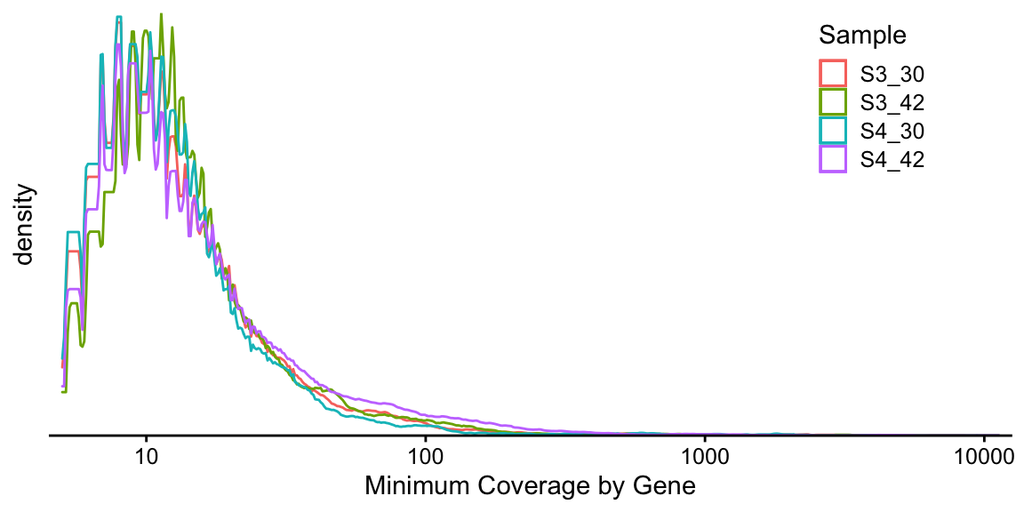

```r
ggplot(data=tibble(),aes(x=peak_height)) +
    geom_density(data=S3_30_df,aes(colour="S3_30"),kernel="rectangular") +
    geom_density(data=S3_42_df,aes(colour="S3_42"),kernel="rectangular") +
    geom_density(data=S4_30_df,aes(colour="S4_30"),kernel="rectangular") +
    geom_density(data=S4_42_df,aes(colour="S4_42"),kernel="rectangular") +
    scale_x_log10(expand=c(0.01,0.01)) +
    scale_y_continuous(expand=c(0,0)) +
    labs(colour="Sample",x="Minimum Coverage by Gene") +
    theme(axis.line.y=element_blank(),
          axis.text.y=element_blank(),
          axis.ticks.y=element_blank(),
          legend.position=c(0.8,0.8))
```

# Choose top 500 peaks for each sample

```r
#sort by peak_height descending
S3_30_df_desc500 <- S3_30_df %>%
    arrange(desc(peak_height)) %>%
    head(n=500)

S3_42_df_desc500 <- S3_42_df %>%
    arrange(desc(peak_height)) %>%
    head(n=500)

S4_30_df_desc500 <- S4_30_df %>%
    arrange(desc(peak_height)) %>%
    head(n=500)

S4_42_df_desc500 <- S4_42_df %>%
    arrange(desc(peak_height)) %>%
    head(n=500)
```

# Find sequences for peaks on the top 500 genes.

```r
S288C_FaF <- Rsamtools::FaFile("../input_annotation/Saccharomyces_cerevisiae.EF4.74.dna.toplevel.shortChrNames.fa")
Rsamtools::indexFa(S288C_FaF)
```

```
## class: FaFile
## path: ../input_.../Saccharomyces_cerevisiae.EF4.74.dna.toplevel.shortChrNames.fa
## index: ../i.../Saccharomyces_cerevisiae.EF4.74.dna.toplevel.shortChrNames.fa.fai
## gzindex: ...../Saccharomyces_cerevisiae.EF4.74.dna.toplevel.shortChrNames.fa.gzi
## isOpen: FALSE
## yieldSize: NA
```

```r
getSeq_gffdf <- function(gff_df,faf=S288C_FaF) {
    out_seqs <- getSeq(faf,
                       makeGRangesFromDataFrame(gff_df) )
    names(out_seqs) <- gff_df %>%
        unite("peakname", chromosome, start, end, strand, ID,sep="_") %>%
        pull(peakname)
    return(out_seqs)
}

select_seqs_above_minwidth <- function(StringSet,minwidth=10) {
    widths <- width(StringSet)
    return( StringSet[ which(widths > minwidth) ])
}
```

## Top 500 peaks, min width 8 (more inclusive)

```r
S3_30_desc500_minwidth8_peakseqs <- getSeq_gffdf(S3_30_df_desc500) %>%
    select_seqs_above_minwidth(minwidth=8) %T>%
    writeXStringSet(paste0(data_output_dir,
                           "/Ssd1_3_30_peaks_FDR_p0_01_desc500_minwidth_8.fa")
                    )

S3_42_desc500_minwidth8_peakseqs <- getSeq_gffdf(S3_42_df_desc500) %>%
    select_seqs_above_minwidth(minwidth=8) %T>%
    writeXStringSet(paste0(data_output_dir,
                           "/Ssd1_3_42_peaks_FDR_p0_01_desc500_minwidth_8.fa")
    )

S4_30_desc500_minwidth8_peakseqs <- getSeq_gffdf(S4_30_df_desc500) %>%
    select_seqs_above_minwidth(minwidth=8) %T>%
    writeXStringSet(paste0(data_output_dir,
                           "/Ssd1_4_30_peaks_FDR_p0_01_desc500_minwidth_8.fa")
                    )

S4_42_desc500_minwidth8_peakseqs <- getSeq_gffdf(S4_42_df_desc500) %>%
    select_seqs_above_minwidth(minwidth=8) %T>%
    writeXStringSet(paste0(data_output_dir,
                           "/Ssd1_4_42_peaks_FDR_p0_01_desc500_minwidth_8.fa")
    )
```

## Top 100 peaks, min width 20 (more exclusive)

```r
S3_30_desc100_minwidth20_peakseqs <- S3_30_df_desc500 %>%
    head(n=100) %>%
    getSeq_gffdf() %>%
    select_seqs_above_minwidth(minwidth=20) %T>%
    writeXStringSet(paste0(data_output_dir,
                           "/Ssd1_3_30_peaks_FDR_p0_01_desc100_minwidth20.fa")
                    )

S3_42_desc100_minwidth20_peakseqs <- S3_42_df_desc500 %>%
    head(n=100) %>%
    getSeq_gffdf() %>%
    select_seqs_above_minwidth(minwidth=20) %T>%
    writeXStringSet(paste0(data_output_dir,
                           "/Ssd1_3_42_peaks_FDR_p0_01_desc100_minwidth20.fa")
    )

S4_30_desc100_minwidth20_peakseqs <- S4_30_df_desc500 %>%
    head(n=100) %>%
    getSeq_gffdf() %>%
    select_seqs_above_minwidth(minwidth=20) %T>%
    writeXStringSet(paste0(data_output_dir,
                           "/Ssd1_4_30_peaks_FDR_p0_01_desc100_minwidth20.fa")
                    )

S4_42_desc100_minwidth20_peakseqs <- S4_42_df_desc500 %>%
    head(n=100) %>%
    getSeq_gffdf() %>%
    select_seqs_above_minwidth(minwidth=20) %T>%
    writeXStringSet(paste0(data_output_dir,
                           "/Ssd1_4_42_peaks_FDR_p0_01_desc100_minwidth20.fa")
    )
```

## MEME motif search

Runs MEME motif search on top 100 peaks. We ran this with MEME 5.1.1

```r
run_MEME <- function(fafile, outputdir, nmotifs = 10, minw = 5, maxw = 8,dry_run = FALSE) {
    cmd_meme <- paste("meme", fafile, "-dna", "-oc", outputdir,
                      "-mod anr", "-nmotifs", nmotifs,
                      "-minw", minw, "-maxw", maxw,
                      "-markov_order 1", "-objfun classic")
    if (!dry_run) {
        system(cmd_meme)
    }
    cmd_meme
}
run_MEME(paste0(data_output_dir,
                           "/Ssd1_3_30_peaks_FDR_p0_01_desc100_minwidth20.fa"),
         paste0(data_output_dir,"/Ssd1_3_30_peaks_FDR_p0_01_desc100_minwidth20_MEME"),
         dry_run = TRUE)
```

```
## [1] "meme ../results//Ssd1_3_30_peaks_FDR_p0_01_desc100_minwidth20.fa -dna -oc ../results//Ssd1_3_30_peaks_FDR_p0_01_desc100_minwidth20_MEME -mod anr -nmotifs 10 -minw 5 -maxw 8 -markov_order 1 -objfun classic"
```

```r
run_MEME(paste0(data_output_dir,
                           "/Ssd1_3_42_peaks_FDR_p0_01_desc100_minwidth20.fa"),
         paste0(data_output_dir,"/Ssd1_3_42_peaks_FDR_p0_01_desc100_minwidth20_MEME"),
         dry_run = TRUE )
```

```
## [1] "meme ../results//Ssd1_3_42_peaks_FDR_p0_01_desc100_minwidth20.fa -dna -oc ../results//Ssd1_3_42_peaks_FDR_p0_01_desc100_minwidth20_MEME -mod anr -nmotifs 10 -minw 5 -maxw 8 -markov_order 1 -objfun classic"
```

```r
run_MEME(paste0(data_output_dir,
                           "/Ssd1_4_30_peaks_FDR_p0_01_desc100_minwidth20.fa"),
         paste0(data_output_dir,"/Ssd1_4_30_peaks_FDR_p0_01_desc100_minwidth20_MEME"),
         dry_run = TRUE )
```

```
## [1] "meme ../results//Ssd1_4_30_peaks_FDR_p0_01_desc100_minwidth20.fa -dna -oc ../results//Ssd1_4_30_peaks_FDR_p0_01_desc100_minwidth20_MEME -mod anr -nmotifs 10 -minw 5 -maxw 8 -markov_order 1 -objfun classic"
```

```r
run_MEME(paste0(data_output_dir,
                           "/Ssd1_3_42_peaks_FDR_p0_01_desc100_minwidth20.fa"),
         paste0(data_output_dir,"/Ssd1_3_42_peaks_FDR_p0_01_desc100_minwidth20_MEME") ,
         dry_run = TRUE)
```

```
## [1] "meme ../results//Ssd1_3_42_peaks_FDR_p0_01_desc100_minwidth20.fa -dna -oc ../results//Ssd1_3_42_peaks_FDR_p0_01_desc100_minwidth20_MEME -mod anr -nmotifs 10 -minw 5 -maxw 8 -markov_order 1 -objfun classic"
```